# Constrast_mean_var

Qing Yu(Sabrina)

February 5, 2017

# Goal of the study

In this report, our goal is to check the distribution of contrasts and check the correctness of covariance matrix generated by fixed root model.

# simluation parameters

We used the lizard tree from the `phylolm` package and associated trait data on these lizard species (just the first trait, which is the first PC axis from a PCA), to find parameter values that are realistic. This trait was analyzed to estimate the shifts in trait evolution using the function `estimate_shift_configuration` from the `l1ou` package. The analysis takes about 2 minutes, so the results were saved in an R data file:

```r
eModel <- estimate_shift_configuration(lizard$tree, lizard$Y)
save(eModel,  file = "eModel_2_5.RData")
```

Next, variables are set up to prepare the simulation.

```r
load("eModel_2_5.RData")
data(lizard.tree, lizard.traits)
lizard <- adjust_data(lizard.tree, lizard.traits[,1])
```

```
## the new tree is normalized: each tip at distance 1 from the root.
## new Y: matrix of size 100 x 1
```

```r
truealpha=eModel$alpha
y0=eModel$intercept
truetheta = y0 + l1ou:::convert_shifts2regions(eModel$tree,
                                eModel$shift.configuration, eModel$shift.values)
nShifts   = length(eModel$shift.configuration) # Total number of shifts
n_tips=length(eModel$tree$tip.label) # Total number of tips
sigma2=eModel$sigma2
shiftnode= eModel$tree$edge[eModel$shift.configuration,1]-n_tips # internal nodes with shift
othernode=(1:(n_tips-1))[-shiftnode] # Other nodes: those without a true shift
```

The tree has $100$ tips and $8$ nodes with a shift at one of its child edges, numbered $72, 51, 41, 63, 93, 61, 84, 18$ (`shiftnode`). At these shifts, the optimal value changed by: -2.91, -2.97, -5.5, -2.39, -2.61, -1.91, -3.7, -3.49 (shift values). The other parameters were estimated to be $\alpha=$ $0.606898$ (`truealpha`) and $\sigma^2=$ $0.0625187$ and an “intercept” `y0` of $0.2488096$. Together with the changes, this intercept gives the following optimal values `truetheta`, one for each edge: $\theta=$ 0.25, 0.25, 0.25, 0.25, 0.25, 0.25, 0.25, 0.25, 0.25, 0.25, 0.25, 0.25, 0.25, -2.36, 0.25, 0.25, 0.25, 0.25, 0.25, 0.25, 0.25, 0.25, 0.25, 0.25, 0.25, 0.25, 0.25, 0.25, 0.25, 0.25, 0.25, -3.45, 0.25, 0.25, 0.25, 0.25, 0.25, 0.25, 0.25, 0.25, 0.25, 0.25, 0.25, 0.25, 0.25, 0.25, 0.25, 0.25, -1.66, -1.66, -1.66, -1.66, -4.57, -4.57, -4.57, -1.66, -1.66, -1.66, -1.66, -1.66, -1.66, -1.66, -1.66, -1.66, -1.66, -1.66, -1.66, -1.66, -1.66, -1.66, -1.66, -1.66, -1.66, -4.05, -1.66, -1.66, -1.66, 0.25, 0.25, 0.25, -2.72, -2.72, -2.72, -2.72, -2.72, -2.72, 0.25, 0.25, 0.25, 0.25, 0.25, 0.25, 0.25, 0.25, 0.25, 0.25, 0.25, -2.72, 0.25, 0.25, 0.25, 0.25, 0.25, 0.25, 0.25, 0.25, 0.25, 0.25, 0.25, 0.25, 0.25, 0.25, 0.25, 0.25, 0.25, 0.25, 0.25, -5.25, 0.25, 0.25, 0.25, 0.25, 0.25, 0.25, 0.25, 0.25, 0.25, 0.25, 0.25, 0.25, 0.25, 0.25, 0.25, 0.25, 0.25, 0.25, 0.25, 0.25, 0.25, 0.25, 0.25, 0.25, 0.25, 0.25, 0.25, 0.25, 0.25, 0.25, 0.25, 0.25, 0.25, 0.25, 0.25, 0.25, 0.25, 0.25, 0.25, 0.25, 0.25, 0.25, 0.25, 0.25, 0.25, -3.24, 0.25, 0.25, 0.25, 0.25, 0.25, 0.25, 0.25, 0.25, 0.25, 0.25, 0.25, 0.25, 0.25, 0.25, 0.25, 0.25, 0.25, 0.25, 0.25, 0.25, 0.25, 0.25, 0.25, 0.25, 0.25, 0.25, 0.25, 0.25, 0.25, 0.25, 0.25, 0.25, 0.25, 0.25.

# Simulation of Y using `rtraitCont`

```r
n_sim=100000
Y_table=matrix(nrow=n_sim, ncol=n_tips, data=NA)
for (i in 1:n_sim) {
  Y  <- rTraitCont(eModel$tree, "OU", theta=truetheta,
                 alpha=truealpha,
                 sigma=sqrt(eModel$sigma2), root.value=y0)
  Y_table[i,]=Y
}
save(Y_table, file="Y_table_2_5.RData")
```

Checking the covariance matrix generated by Y is the same as the covariance matrix generated by fixed root from the definition.

### Checking whether mu from eModel and mean of tips from Y are significant different

```r
load("Y_table_2_5.RData")
truemu=as.matrix(apply(Y_table,2,mean))
#cbind(eModel$mu,truemu)
head(eModel$mu)
```

```
##           [,1]
## [1,] 0.2488096
## [2,] 0.2488096
## [3,] 0.2488096
## [4,] 0.2488096
## [5,] 0.2488096
## [6,] 0.2488096
```

```r
head(truemu)
```

```
##           [,1]
## [1,] 0.2485854
## [2,] 0.2478851
## [3,] 0.2483680
## [4,] 0.2493011
## [5,] 0.2482424
## [6,] 0.2481869
```

```r
2*sqrt(eModel$sigma2/n_sim) ## 2*standard error
```

```
## [1] 0.001581375
```

```r
all.equal(eModel$mu,truemu, scale=1)
```

```
## [1] "Mean absolute difference: 0.0004177774"
```

```r
all.equal(eModel$mu,truemu,tolerance= 2*sqrt(eModel$sigma2/n_sim), scale=1)
```

```
## [1] TRUE
```

mu from eModel and mean of tips from Y are not significant different

### Compute the observed covariance matrix of Y

```r
cov_table=matrix(nrow=n_tips,ncol=n_tips,data=NA)
for (noderow in 1:n_tips){
  for(nodecol in 1:n_tips){
    sum=0
    for(sim in 1:n_sim){
      sum=(Y_table[sim,noderow]-eModel$mu[noderow])*(Y_table[sim,(nodecol)]-eModel$mu[nodecol])+sum
    }
    cov_table[noderow,nodecol]=sum/n_sim
  }
}
save(cov_table,file="Cov_table_2_5.RData")
```

### Calculate the true covariance matrix with fixed root model

```r
tij=vcv(lizard.tree)  # the time spent on each edge
treeheight=max(tij)
dij=2*(treeheight-tij)
##vrandom=1/(2*truealpha)*exp(-truealpha*dij) # Sigma generated by OUrandomRoot model
vfix=1/(2*truealpha)*exp(-truealpha*dij)*(1-exp(-2*truealpha*tij))
```

### Check agreement between observed and true covariance matrix of Y

```r
load("Cov_table_02_05.RData")
# matrix to be compared with
true_cov=vfix*eModel$sigma2
matequal <- function(x, y)
    all(abs(x-y)<=4*sqrt(1/n_sim)*eModel$sigma2*max(diag(vfix)))

matequal(true_cov,cov_table)
```

```
## [1] FALSE
```

```r
sqrt(1/n_sim)*eModel$sigma2*max(diag(vfix))
```

```
## [1] 0.0001144927
```

```r
all.equal(true_cov,cov_table,scale=1)
```

```
## [1] "Attributes: < Length mismatch: comparison on first 1 components >"
## [2] "Mean absolute difference: 9.341627e-05"
```

```r
all.equal(true_cov,cov_table,scale=1,tolerance=4*sqrt(1/n_sim)*eModel$sigma2*max(diag(vfix)))
```

```
## [1] "Attributes: < Length mismatch: comparison on first 1 components >"
```

```r
true_cov[1:6,1:6]
```

```
##                    ahli     allogus rubribarbus       imias     sagrei
## ahli        0.036205756 0.028639694 0.023190653 0.009937628 0.00630642
## allogus     0.028639694 0.036205756 0.023190653 0.009937628 0.00630642
## rubribarbus 0.023190653 0.023190653 0.036205756 0.009937628 0.00630642
## imias       0.009937628 0.009937628 0.009937628 0.036205756 0.00630642
## sagrei      0.006306420 0.006306420 0.006306420 0.006306420 0.03620576
## bremeri     0.006306420 0.006306420 0.006306420 0.006306420 0.02237467
##                bremeri
## ahli        0.00630642
## allogus     0.00630642
## rubribarbus 0.00630642
## imias       0.00630642
## sagrei      0.02237467
## bremeri     0.03620576
```

```r
cov_table[1:6,1:6]
```

```
##             [,1]        [,2]        [,3]        [,4]        [,5]
## [1,] 0.036729559 0.028899400 0.023311163 0.010051731 0.006421107
## [2,] 0.028899400 0.036206617 0.023221863 0.010086038 0.006436202
## [3,] 0.023311163 0.023221863 0.036095669 0.009966072 0.006466176
## [4,] 0.010051731 0.010086038 0.009966072 0.036252477 0.006567512
## [5,] 0.006421107 0.006436202 0.006466176 0.006567512 0.036003414
## [6,] 0.006327824 0.006347724 0.006456822 0.006468972 0.022192240
##             [,6]
## [1,] 0.006327824
## [2,] 0.006347724
## [3,] 0.006456822
## [4,] 0.006468972
## [5,] 0.022192240
## [6,] 0.035968925
```

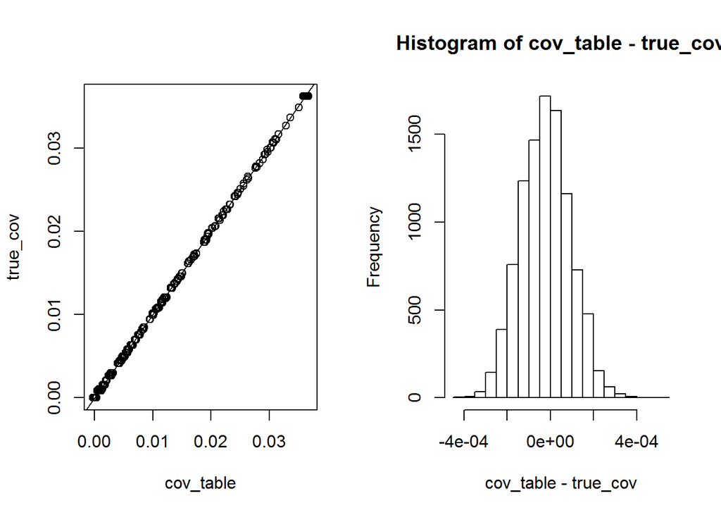

```r
layout(matrix(1:2,1,2))
plot(cov_table,true_cov); abline(a=0, b=1)
hist(cov_table-true_cov)
```

### square root of covariance matrix

We first calculate it with `sqrt_OU_covariance`, then check that it is in agreement with the true covariance `vfix` calculated earlier.

```r
REf = sqrt_OU_covariance(lizard.tree, alpha=truealpha,
                        root.model = "OUfixedRoot",normalize.tree.height=T ,
                        check.order=F, check.ultrametric=F)

Dtf  = t(REf$sqrtInvSigma)
Bf   = REf$sqrtSigma
all.equal(Dtf%*%Bf,diag(100), scale=1)
```

```
## [1] TRUE
```

```r
Ind_fix=Dtf%*%vfix%*%t(Dtf)
all.equal(Ind_fix,diag(100), scale=1)
```

```
## [1] TRUE
```

“sqrt_OU_covariance” function caculates the square root of covariance matrix correcly.

# Calculate Contrasts

```r
contrast_table=matrix(nrow=n_sim, ncol=n_tips, data=NA)
for (i in 1:nrow(Y_table)) {
  contrast_table[i,]=Dtf%*%(Y_table[i,] - eModel$mu)
}
save(contrast_table, file="contrast_table_2_5.RData")
```

### Check whether contrast mean is equal to 0

```r
load('contrast_table_2_5.RData')
head(colMeans(contrast_table))
```

```
## [1]  0.0002936259  0.0005437081 -0.0011580854 -0.0014622974  0.0013248416
## [6] -0.0001489877
```

```r
max(abs(colMeans(contrast_table)))
```

```
## [1] 0.001822459
```

```r
colMeans(contrast_table)
```

```
##   [1]  2.936259e-04  5.437081e-04 -1.158085e-03 -1.462297e-03  1.324842e-03
##   [6] -1.489877e-04 -1.082437e-04  3.153187e-04  1.092892e-03 -3.949626e-04
##  [11] -6.906195e-04 -3.593490e-04 -4.397628e-04  1.502403e-03  6.004795e-04
##  [16]  1.532167e-04 -4.803428e-04  1.086476e-03 -1.124537e-03  3.234783e-04
##  [21] -2.055787e-04  1.240912e-03  5.511492e-04  1.923877e-04 -1.438383e-04
##  [26]  1.655792e-03 -6.682487e-04 -1.707682e-03 -1.133258e-03  3.482009e-04
##  [31]  3.939282e-04 -4.521101e-05  7.937092e-04 -7.300490e-04 -5.816772e-04
##  [36]  2.410313e-04  1.580529e-04  7.753134e-04  1.357171e-03 -3.434553e-04
##  [41] -1.062812e-03 -8.143168e-04  9.046964e-04  3.582746e-04 -1.822459e-03
##  [46] -7.308433e-04 -1.134198e-03  1.404343e-05  7.893330e-04 -3.609898e-04
##  [51]  9.241683e-04 -8.765625e-04 -4.132106e-04 -3.312742e-04  3.813810e-04
##  [56] -3.807294e-04 -7.968394e-04 -7.978669e-05  1.270336e-04 -4.466186e-04
##  [61]  7.032605e-04 -4.764006e-04  6.274901e-04 -1.207996e-03 -9.376294e-04
##  [66]  2.209574e-04 -2.858502e-04 -1.292109e-03 -5.827875e-04  1.752016e-04
##  [71]  2.847665e-04 -1.321285e-03 -8.194454e-04  6.150952e-05 -7.989488e-04
##  [76] -1.200301e-03  4.047343e-04  5.518316e-05  4.542254e-04  4.538062e-04
##  [81] -3.905190e-04  4.750033e-05  5.819572e-04  1.007289e-03  3.284101e-04
##  [86]  4.645462e-05  8.556082e-04  3.988658e-04 -2.834460e-04  3.224534e-04
##  [91] -4.945792e-04  1.423454e-03 -2.226035e-04 -1.192475e-03  7.468512e-04
##  [96]  2.900539e-04 -3.529061e-04 -1.232649e-03 -4.025506e-04 -2.648512e-04
```

The mean of all contrasts are all zeros.

### Check whether contrast variance is equal to sigma2

```r
ss=function(x){
  sum(x^2)/length(x)
}
convar=apply(contrast_table,2,ss)
convar
```

```
##   [1] 0.06226439 0.06258969 0.06228206 0.06185538 0.06231495 0.06242140
##   [7] 0.06256224 0.06219234 0.06216682 0.06240147 0.06222383 0.06200548
##  [13] 0.06282155 0.06245075 0.06279975 0.06258275 0.06251883 0.06247997
##  [19] 0.06232777 0.06258758 0.06236507 0.06259616 0.06267557 0.06242355
##  [25] 0.06229275 0.06260808 0.06221274 0.06243247 0.06235870 0.06259370
##  [31] 0.06246769 0.06242847 0.06288057 0.06255914 0.06274826 0.06257278
##  [37] 0.06292527 0.06257065 0.06299845 0.06257913 0.06272465 0.06208273
##  [43] 0.06248409 0.06191161 0.06240520 0.06221114 0.06242529 0.06244330
##  [49] 0.06259906 0.06223723 0.06279803 0.06269686 0.06249820 0.06199016
##  [55] 0.06256578 0.06227071 0.06227814 0.06239336 0.06227895 0.06250814
##  [61] 0.06252155 0.06262676 0.06236870 0.06257509 0.06268641 0.06331554
##  [67] 0.06237474 0.06266784 0.06249402 0.06252180 0.06290999 0.06252153
##  [73] 0.06268941 0.06249738 0.06239644 0.06212852 0.06292058 0.06233895
##  [79] 0.06295462 0.06280390 0.06239385 0.06251193 0.06269901 0.06250260
##  [85] 0.06262733 0.06293786 0.06249215 0.06245859 0.06262924 0.06207798
##  [91] 0.06244999 0.06254036 0.06251645 0.06248630 0.06202160 0.06285781
##  [97] 0.06236344 0.06288143 0.06249279 0.06212581
```

```r
mean(convar)
```

```
## [1] 0.06249321
```

```r
eModel$sigma2
```

```
## [1] 0.06251866
```

The mean of variance of contrasts is the same as sigma of the phylogenetic model.